# Görselleştirme Teknikleri Dönem Sonu Projesi

H. Simay Özgül

2024-07-16

# Kalp Rahatsızlığına İlişkin Veri Analizi

## Veri Setinin Tanımı:

```r
library(readr)
data <- read.csv("C:/Users/w10/Downloads/Heart_Disease.csv", header= TRUE, sep=",")
```

16 değişken ve 3674 gözlemden oluşan veri seti, koroner kalp hastalığı için prediktif faktörler ve risk değerlendirmesinin yapılması amacını taşımaktadır. Veri seti Kaggle’dan bulunmuş olup linki aşağıda verilmiştir.

https://www.kaggle.com/datasets/mahdifaour/heart-disease-dataset

## Veri Setinin Düzeltilmesi:

Öncelikle veri setinde varsa boş gözlemlerin silinmesi için aşağıdaki kod yazılmıştır.

```r
library(dplyr)
c_data <- data %>%
  filter_all(all_vars(!is.na(.)))
```

Daha sonrasında ise str() fonksiyonu ile değişkenlerin R’a nasıl tanımlandığına bakılmış, gerekli görülen değişkenlerin türleri düzenlenmiştir.

```r
c_data$sex <- factor(c_data$sex, levels = c("male", "female"))
c_data$smokingStatus <- factor(c_data$smokingStatus, levels = c("no","yes"))
c_data$education <- factor(c_data$education,
                           levels = c("1","2","3","4"),
                           ordered= TRUE)
c_data$BPMeds <- factor(c_data$BPMeds, levels = c("0","1"))
c_data$prevalentStroke <- factor(c_data$prevalentStroke, levels = c("0","1"))
c_data$prevalentHyp <- factor(c_data$prevalentHyp, levels = c("0","1"))
c_data$diabetes <- factor(c_data$diabetes, levels = c("no","yes"))
c_data$CHDRisk <- factor(c_data$CHDRisk, levels = c("no","yes"))

str(c_data)
```

```
## 'data.frame':    3674 obs. of  16 variables:
##  $ sex            : Factor w/ 2 levels "male","female": 1 2 1 2 2 2 2 2 1 1 ...
##  $ age            : int  39 46 48 61 46 43 63 45 52 43 ...
##  $ education      : Ord.factor w/ 4 levels "1"<"2"<"3"<"4": 4 2 1 3 3 2 1 2 1 1 ...
##  $ smokingStatus  : Factor w/ 2 levels "no","yes": 1 1 2 2 2 1 1 2 1 2 ...
##  $ cigsPerDay     : int  0 0 20 30 23 0 0 20 0 30 ...
##  $ BPMeds         : Factor w/ 2 levels "0","1": 1 1 1 1 1 1 1 1 1 1 ...
##  $ prevalentStroke: Factor w/ 2 levels "0","1": 1 1 1 1 1 1 1 1 1 1 ...
##  $ prevalentHyp   : Factor w/ 2 levels "0","1": 1 1 1 2 1 2 1 1 2 2 ...
##  $ diabetes       : Factor w/ 2 levels "no","yes": 1 1 1 1 1 1 1 1 1 1 ...
##  $ totChol        : int  195 250 245 225 285 228 205 313 260 225 ...
##  $ sysBP          : num  106 121 128 150 130 ...
##  $ diaBP          : num  70 81 80 95 84 110 71 71 89 107 ...
##  $ BMI            : num  27 28.7 25.3 28.6 23.1 ...
##  $ heartRate      : int  80 95 75 65 85 77 60 79 76 93 ...
##  $ glucose        : int  77 76 70 103 85 99 85 78 79 88 ...
##  $ CHDRisk        : Factor w/ 2 levels "no","yes": 1 1 1 2 1 1 2 1 1 1 ...
```

## Histogram Grafiği:

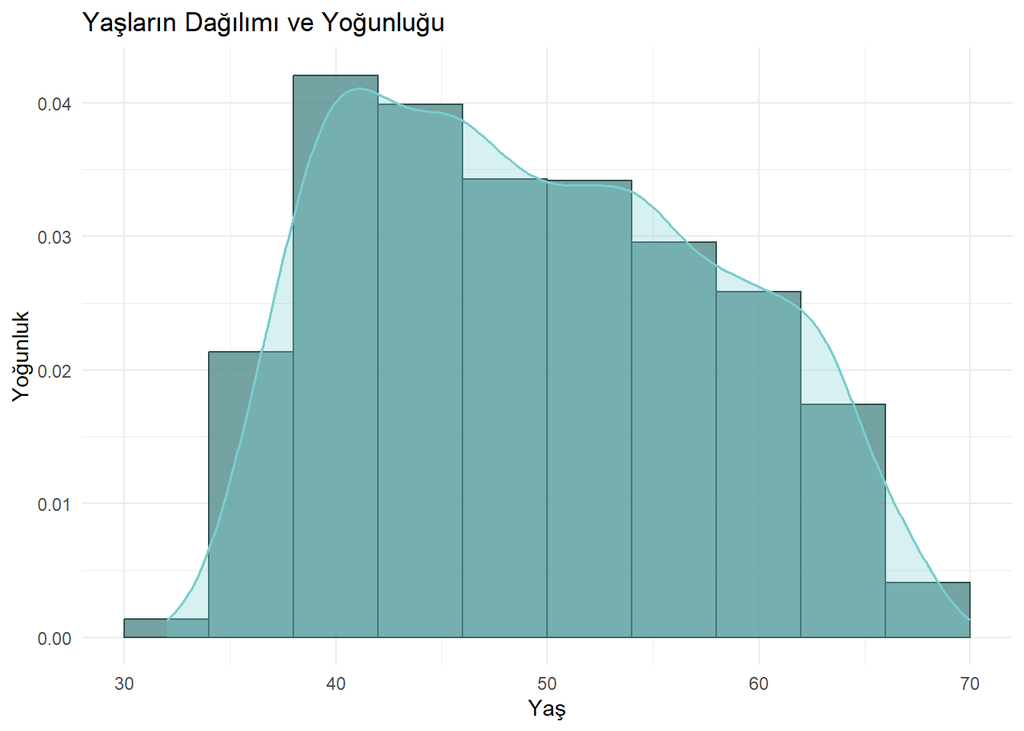

```r
library(ggplot2)
ggplot(c_data, aes(x = age)) +
  geom_histogram(aes(y = ..density..), binwidth = 4, fill = "#528B8B", color = "#2F4F4F", alpha = 0.8) +
  geom_density(alpha = 0.3, fill = "#79CDCD", color = "#79CDCD", size = 0.7) +
  labs(title = "Yaşların Dağılımı ve Yoğunluğu",
       x = "Yaş",
       y = "Yoğunluk") +
  theme_minimal()
```

*Veri setinde bulunan bireylerin yaş dağılımlarını incelemek adına histogram ve yoğunluk grafiği çizilmiştir.*

Grafik incelendiğinde veri setinin sağa çarpık olduğu görülmekte olup, genel olarak bireylerin yaşının 40 ile 60 arasında yoğunlaştığı söylenebilir.

## Çubuk Grafiği (Bar Plot):

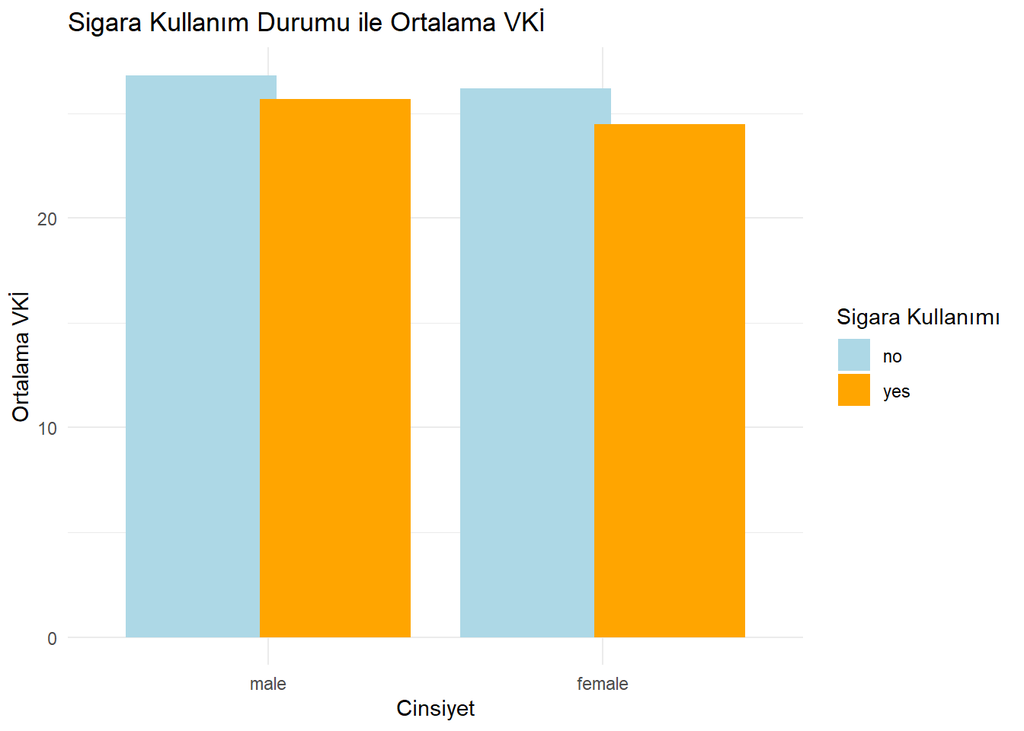

```r
mean_BMI <- aggregate(BMI ~ sex + smokingStatus, data = c_data, FUN = mean)
colors <- c("male" = "palegreen3", "female" = "pink1")
smoking_colors <- c("no" = "lightblue", "yes" = "orange")
ggplot(mean_BMI, aes(x = sex, y = BMI, fill = smokingStatus)) +
  geom_bar(stat = "identity", position = position_dodge(width = 0.8)) +
  scale_fill_manual(values = smoking_colors) +
  theme_minimal() +
  labs(title = "Sigara Kullanım Durumu ile Ortalama VKİ",
       x = "Cinsiyet",
       y = "Ortalama VKİ",
       fill = "Sigara Kullanımı")
```

*Bireylerin sigara kullanım durumuna göre vücut kitle indekslerinin nasıl değişebileceği, cinsiyet bazında incelenmek istendiği için bu grafik elde edilmiştir.*

Bu grafik, sigara kullanımının ortalama VKİ (Vücut Kitle İndeksi) üzerinde olumsuz bir etkisi olduğunu göstermektedir; sigara kullanan bireylerin VKİ’si, sigara kullanmayanlara göre daha düşük gözükmektedir. Bununla birlikte, cinsiyetler arasında VKİ değerlerinde büyük bir fark olmadığı söylenebilir.

## Kontür Çizgili Saçılım Grafiği (Kernel Density Estimate Contour Plot):

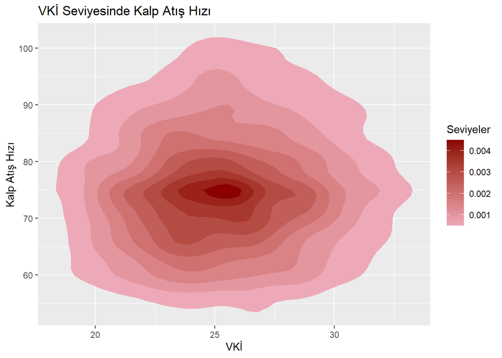

```r
library(ggplot2)
ggplot(c_data, aes(x=BMI, y=heartRate) ) +
  stat_density_2d(aes(fill= ..level..), geom = "polygon")+
  scale_fill_gradient(low = "pink2", high = "red4")+
  labs(title = "VKİ Seviyesinde Kalp Atış Hızı",
       x = "VKİ",
       y = "Kalp Atış Hızı",
       fill = "Seviyeler")
```

*Ele alınan bu grafikte VKİ (Vücut Kitle İndeksi) seviyelerine göre, bireylerin kalp atış hızlarının yoğunluğu incelenmek istenmiştir.*

En yoğun bölgeler, grafiğin ortasındaki daha koyu kırmızı alanlardır. Grafikteki en yoğun alan yaklaşık olarak VKİ 22-28 aralığında ve kalp atış hızı 70-85 aralığında bulunmaktadır.

## Saçılım Matrisi (Scatterplot Matrix):

```r
iliski <- c_data[,c(10,13,15)]

cor(iliski)
```

```
##            totChol        BMI    glucose
## totChol 1.00000000 0.12063977 0.05160172
## BMI     0.12063977 1.00000000 0.08377442
## glucose 0.05160172 0.08377442 1.00000000
```

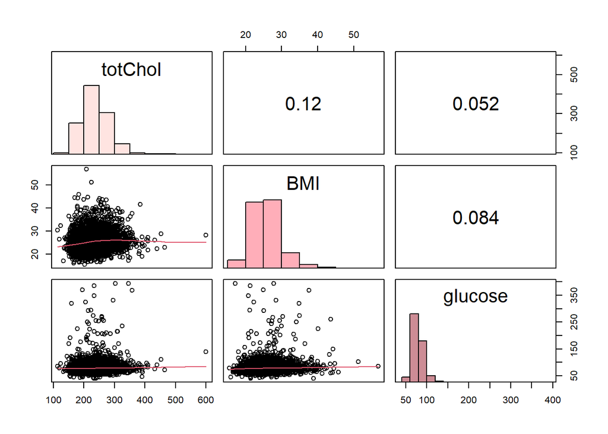

```r
panel.cor <- function(x, y, digits=2, prefix="", cex.cor) {
  usr <- par("usr"); on.exit(par(usr))
  par(usr=c(0,1,0,1))
  r = cor(x, y)
  txt <- format(c(r, 0.123456789), digits=digits)[1]
  txt <- paste(prefix, txt, sep="")
  if (missing(cex.cor)) cex <- 0.8/strwidth(txt)
  text(0.5, 0.5, txt, cex=2)
}

panel.hist <- function(x, col = "#8B475D", ...) {
  usr <- par("usr"); on.exit(par(usr))
  par(usr = c(usr[1:2], 0, 1.5))
  h <- hist(x, plot = FALSE)
  breaks <- h$breaks; nB <- length(breaks)
  y <- h$counts; y <- y / max(y)
  rect(breaks[-nB], 0, breaks[-1], y, col = col, ...)
}

pairs(iliski,
      diag.panel = function(x, ...) {
        if (identical(x, iliski[, 1])) {
          panel.hist(x, col = "#FFE4E1", ...)
        } else if (identical(x, iliski[, 2])) {
          panel.hist(x, col = "#FFAEB9", ...)
        } else if (identical(x,iliski[, 3])) {
          panel.hist(x, col = "#CD8C95", ...)
        }
      },
      lower.panel = panel.smooth,
      upper.panel = panel.cor)
```

*Bireylerdeki kolesterol ve glikoz seviyeleri ile VKİ’ne ait korelasyon katsayıları, histogram ve saçılım grafikleri incelenmek üzere bu grafik elde edilmiştir.*

Korelasyon katsayılarına bakıldığında, üç değişken için de elde edilen değerlerin düşük olduğu görülmektedir. Dolayısıyla değişkenler arasındaki ilişkinin anlamlılık seviyelerinin düşük olduğu söylenebilir. Değişkenlerin histogram grafikleri için, üçünün de sağa çarpık bir dağılıma sahip olduğu görülür. Kolesterol ve VKİ saçılım matrisi, kolesterol ile VKİ arasında zayıf bir ilişki olduğunu; kolesterol ve glikoz saçılım matrisi, kolesterol ile glikoz seviyeleri arasında neredeyse hiçbir ilişki olmadığını; VKİ ve glikoz saçılım matrisi ise VKİ ile glikoz seviyeleri arasında zayıf bir ilişki olduğunu göstermektedir.

## Pasta Grafiği (Pie Chart):

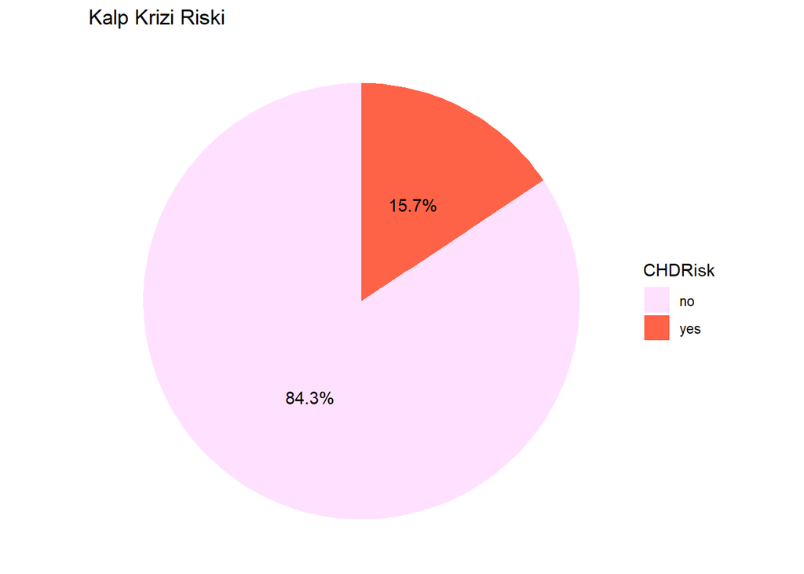

```r
library(plotly)
library(dplyr)
cross<-as.data.frame(prop.table(table(c_data$CHDRisk)))
colnames(cross) <- c("CHDRisk", "Freq")
cross <- cross %>%
  mutate(label = paste0(round(Freq * 100, 1), "%"))

ggplot(cross, aes(x = "", y = Freq, fill = CHDRisk)) +
  geom_bar(width = 1, stat = "identity") +
  coord_polar(theta = "y") +
  labs(title = "Kalp Krizi Riski") +
  theme_void() +
  theme(legend.position = "right")+
  geom_text(aes(label = label), position = position_stack(vjust = 0.5))+
  scale_fill_manual(values = c("no" = "#FFE1FF", "yes" = "#FF6347"))
```

*Veri setindeki bireylerin yüzde kaçının kalp krizi riski taşıdığına bakılmak istendiği için pasta grafiği elde edilmiştir.*

Risk taşıyanlar için, grafikte özellikle daha çarpıcı bir renk tercih edilmiştir. Bireylerin %84.3’ü risk taşımıyorken, %15.7’sinin risk taşıdığı görülmektedir.

## Barcode Plot:

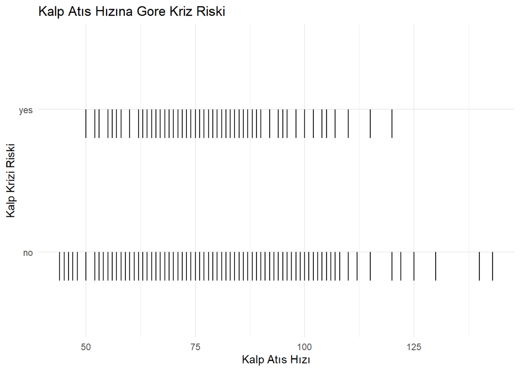

```r
ggplot(c_data, aes(x = heartRate, y = CHDRisk)) +
  geom_segment(aes(xend = heartRate, yend = as.numeric(CHDRisk) - 0.2),
               linetype = "solid", size = 0.5) +
  theme_minimal() +
  labs(title = "Kalp Atıs Hızına Gore Kriz Riski", x = "Kalp Atıs Hızı", y = "Kalp Krizi Riski") +
  scale_y_discrete(labels = c("no", "yes"))
```

*Elde edilen barcode plot, kalp krizi riski olan ve olmayan bireylerin kalp atış hızlarının nasıl dağıldığını görselleştirmek amacıyla oluşturulmuştur.*

## Balon Grafiği (Balloon Chart):

```r
c_data2 <- xtabs(~ CHDRisk+smokingStatus+sex+diabetes, data=c_data)
c_data2
```

```
## , , sex = male, diabetes = no
##
##        smokingStatus
## CHDRisk   no  yes
##     no   511  768
##     yes   95  205
##
## , , sex = female, diabetes = no
##
##        smokingStatus
## CHDRisk   no  yes
##     no  1038  705
##     yes  151   82
##
## , , sex = male, diabetes = yes
##
##        smokingStatus
## CHDRisk   no  yes
##     no    16   11
##     yes   13    7
##
## , , sex = female, diabetes = yes
##
##        smokingStatus
## CHDRisk   no  yes
##     no    23   12
##     yes   10    5
```

```r
c_data2_df <- as.data.frame(ftable(c_data2))
c_data2_df
```

```
##    CHDRisk smokingStatus    sex diabetes Freq
## 1       no            no   male       no  511
## 2      yes            no   male       no   95
## 3       no           yes   male       no  768
## 4      yes           yes   male       no  205
## 5       no            no female       no 1038
## 6      yes            no female       no  151
## 7       no           yes female       no  705
## 8      yes           yes female       no   82
## 9       no            no   male      yes   16
## 10     yes            no   male      yes   13
## 11      no           yes   male      yes   11
## 12     yes           yes   male      yes    7
## 13      no            no female      yes   23
## 14     yes            no female      yes   10
## 15      no           yes female      yes   12
## 16     yes           yes female      yes    5
```

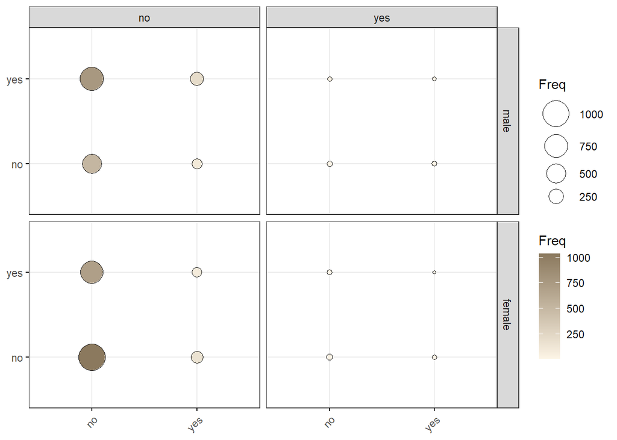

```r
library(ggpubr)
ggballoonplot(
  c_data2_df, x = "CHDRisk", y = "smokingStatus",
  size = "Freq", fill = "Freq",
  facet.by = c("sex","diabetes"),
  ggtheme = theme_bw()) +
  scale_fill_gradient(low = "#FDF5E6", high = "#8B795E")
```

*Bu balon grafiği, cinsiyet ve sigara kullanım durumu ile kalp krizi riski arasındaki ilişkiyi görselleştirmektedir.*

## Ayçiçeği Grafiği (Sunflower Plot):

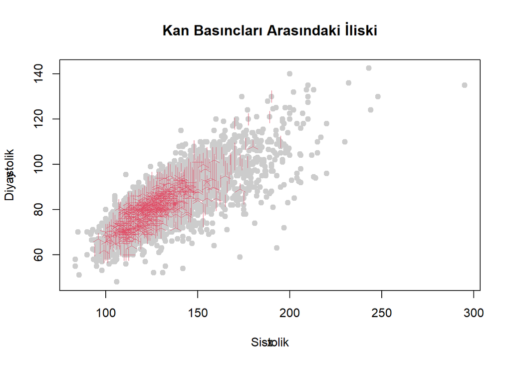

```r
x <- c_data$sysBP
y <- c_data$diaBP
sunflowerplot(x, y, pch = 19, col = "gray80", cex = 1, cex.fact = 1, size = 0.08, seg.lwd = 0.8)
title(main = "Kan Basıncları Arasındaki İliski", xlab = "Sistolik", ylab = "Diyastolik")
```

*Bu grafiğin tercih edilmesinin amacı, sistolik ve diyastolik kan basınçları arasındaki ilişkiyi ölçerken, bir noktada birden fazla gözlem olduğu için Sunflower Plot yardımıyla daha anlaşılır olacak şekilde incelemek istenilmesidir.*

Grafik, sysBP ve diaBP arasında genel bir doğrusal ilişki olduğunu göstermektedir. Sistolik kan basıncı arttıkça, diyastolik kan basıncı da artma eğilimindedir. Bu ilişki, sağlıklı bireylerde beklenen bir durumdur çünkü kan basıncı komponentlerinin genellikle birlikte arttığı bilinmektedir.